# Research Project

Derek Bowdle  
Quantum Computation  
EN.605. 728. 81  
Fall 2022

## Quantum Programming Project

The following is a tutorial on how to implement quantum random walks using Cirq. It will cover: Classical Random Walks, Quantum Walks, First Hitting Times for both.

```python
#importing
try:
    import cirq
except ImportError:
    print("installing cirq...")
    !pip install --quiet cirq
    print("installed cirq.")
    import cirq
try:
    from hmmviz import TransGraph
except ImportError:
    print("installing hmmviz...")
    !pip install hmmviz
    print("installed hmmviz.")
    from hmmviz import TransGraph
import random
import numpy as np
from matplotlib import pyplot as plt
import scipy
import scipy.special
import pandas as pd
from cirq.contrib.svg import SVGCircuit
```

### 1 Classical Random Walk

#### 1.1 One Dimensional Simple Random Walk

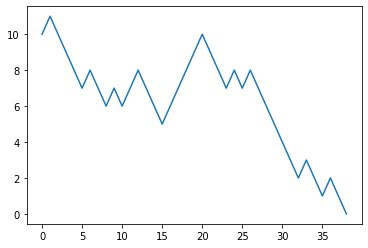

```python
z = 10 #initial position
S = z
vals = []

for i in range(100):
  vals.append(S)
  Y = random.randint(0,1)
  X = 2*Y-1
  S = S+X
  if S == 0:
    break
vals.append(S)

plt.plot(range(len(vals)),vals)
```

#### 1.2 One Dimensional Hitting Time

```python
def walk():
  z = 10 #initial position
  S = z
  vals = []
  for i in range(100):
    vals.append(S)
    Y = random.randint(0,1)
    X = 2*Y-1
    S = S+X
    if S == 0:
      return len(vals)
  return -1

hitting_times = []

for i in range(10000):
  x = walk()
  if x != -1:
    hitting_times.append(x)
```

1.2.1 Hitting Time Ratio

```python
print(len(hitting_times)/10000)
```

```
0.3221
```

1.2.2 First Hitting Time

```python
print(min(hitting_times))
```

```
10
```

1.2.3 Average Hitting Time given it hits

```python
print(sum(hitting_times)/len(hitting_times))
```

```
53.458553244334055
```

Random walk on a simple graph

```python
A = np.array([[0,0.5,0,0.5],[0.5,0,0.5,0],[0,0.5,0,0.5],[0.5,0,0.5,0]])
X = np.array([[0],[0],[1],[0]])
print('step 0:')
print(X,end='\n\n')
print('step 1:')
print(A.dot(X),end='\n\n')
print('step 2:')
print(A.dot(A).dot(X))
```

```
step 0:
[[0]
 [0]
 [1]
 [0]]

step 1:
[[0. ]
 [0.5]
 [0. ]
 [0.5]]

step 2:
[[0.5]
 [0. ]
 [0.5]
 [0. ]]
```

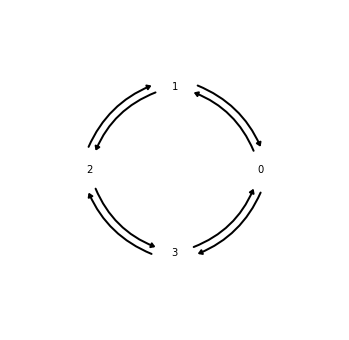

```python
graph = TransGraph.from_array(A,['0','1','2','3'])

# looks best on square figures/axes
fig = plt.figure(figsize=(6, 6))

graph.draw()

plt.show()
```

### 2 Quantum Random Walk

#### 2.1 Quantum implementation of graph

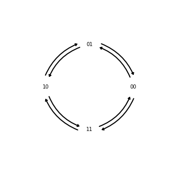

```python
graph = TransGraph.from_array(A,['00','01','10','11'])

# looks best on square figures/axes
fig = plt.figure(figsize=(6, 6))

graph.draw()
plt.show()
```

```python
coin_bits = 1 # the number of states the coin can take is 2^n bits
node_bits = 2 # the number of nodes is 2^n bits
```

```python
def walk_step():
  # ***something to note: the least signifigant bit for output is the highest bit***
  # ***for easy calculation purposes we set the most significant bits to be our hadamard coin bits***
  yield cirq.H.on(qubits[0]) #set 2 operations
  coin_controls = [qubits[v] for v in range(0,coin_bits)] #used for connecting the operation to the coin

  for i in range(coin_bits,coin_bits+node_bits): #add 1 operation
    controls = [qubits[v] for v in range(i+1,coin_bits+node_bits)]
    yield cirq.X.on(qubits[i]).controlled_by(*controls).controlled_by(*coin_controls)

  yield cirq.X.on(qubits[0]) #flip coin to switch to second operation

  for i in range(coin_bits+node_bits-1,coin_bits-1,-1): #sub 1 operation
    controls = [qubits[v] for v in range(i+1,coin_bits+node_bits)]
    yield cirq.X.on(qubits[i]).controlled_by(*controls).controlled_by(*coin_controls)

  yield cirq.X.on(qubits[0]) #flip coin back to first operation
qubits = cirq.LineQubit.range(coin_bits+node_bits)
circuit = cirq.Circuit()
circuit.append(walk_step())
SVGCircuit(circuit)
```

[output not shown]

```
WARNING:matplotlib.font_manager:findfont: Font family ['Arial'] not found. Falling back to DejaVu Sans.
```

```python
def initialize():
  #if the bit order for the output gets wierd sometimes so i initialize circut with a controlled x gate, operation is reverable so it does not affect the rest of the circut

  all_controls = [qubits[v] for v in range(0,coin_bits+node_bits-1)]
  yield cirq.X.on(qubits[coin_bits+node_bits-1]).controlled_by(*all_controls)
  yield cirq.X.on(qubits[coin_bits+node_bits-1]).controlled_by(*all_controls)
```

```python
qubits = cirq.LineQubit.range(coin_bits+node_bits)
circuit = cirq.Circuit()

circuit.append(initialize())
circuit.append(walk_step())
print(circuit)

s  = cirq.Simulator()

print('Simulate the circuit:')
for i in range(8):
  circuit = cirq.Circuit()
  circuit.append(initialize())
  circuit.append(walk_step())

  print(i)
  results = s.simulate(circuit, initial_state=i)
  state = circuit.final_state_vector(initial_state=i)
  print(results)
  print(state)

  circuit.append(cirq.measure(*qubits, key='x'))
  result = s.run(circuit, repetitions=1000)
  final = result.histogram(key='x')
  print(final)
# checking that outputs are correct for first step
```

```
0: ───@───@───H───@───@───X───@───@───X───
      │   │       │   │       │   │
1: ───@───@───────X───┼───────┼───X───────
      │   │       │   │       │   │
2: ───X───X───────@───X───────X───@───────
Simulate the circuit:
0
measurements: (no measurements)

qubits: (cirq.LineQubit(0), cirq.LineQubit(1), cirq.LineQubit(2))
output vector: 0.707|011⟩ + 0.707|101⟩

phase:
output vector: |⟩
[ 0.        +0.j  0.        +0.j  0.        +0.j  0.70710678+0.j
 -0.        +0.j  0.70710678+0.j -0.        +0.j -0.        +0.j]
Counter({5: 512, 3: 488})
1
measurements: (no measurements)

qubits: (cirq.LineQubit(0), cirq.LineQubit(1), cirq.LineQubit(2))
output vector: 0.707|000⟩ + 0.707|110⟩

phase:
output vector: |⟩
[ 0.70710678+0.j  0.        +0.j  0.        +0.j  0.        +0.j
 -0.        +0.j -0.        +0.j  0.70710678+0.j -0.        +0.j]
Counter({3: 505, 5: 495})
2
measurements: (no measurements)

qubits: (cirq.LineQubit(0), cirq.LineQubit(1), cirq.LineQubit(2))
output vector: 0.707|001⟩ + 0.707|111⟩

phase:
output vector: |⟩
[ 0.        +0.j  0.70710678+0.j  0.        +0.j  0.        +0.j
 -0.        +0.j -0.        +0.j -0.        +0.j  0.70710678+0.j]
Counter({3: 525, 5: 475})
3
```

[output cut: 39 more lines]

```
output vector: |⟩
[ 0.        +0.j  0.70710678+0.j  0.        +0.j  0.        +0.j
 -0.        +0.j -0.        +0.j -0.        +0.j -0.70710678+0.j]
Counter({3: 516, 5: 484})
7
measurements: (no measurements)

qubits: (cirq.LineQubit(0), cirq.LineQubit(1), cirq.LineQubit(2))
output vector: 0.707|010⟩ - 0.707|100⟩

phase:
output vector: |⟩
[ 0.        +0.j  0.        +0.j  0.70710678+0.j  0.        +0.j
 -0.70710678+0.j -0.        +0.j -0.        +0.j -0.        +0.j]
Counter({5: 526, 3: 474})
```

#### 2.2 Quantum Walk First Hitting Time

Starting at node 2 evaluate the likelihood we get to node 0 and check if it is the first hitting time

```python
qubits = cirq.LineQubit.range(coin_bits+node_bits)
circuit = cirq.Circuit()

s  = cirq.Simulator()
circuit.append(initialize())

for i in range(1,3):
  print('Step ',end='')
  print(i,end=': \n')
  circuit.append(walk_step())
  results = s.simulate(circuit, initial_state=2)
  state = circuit.final_state_vector(initial_state=2)
  print(results)
  print(state)
  for i in range(int(len(state)/2)):
    print('Pr(state ',end='')
    print(i,end=')=')
    print(state[i]**2+state[i+int(len(state)/2)]**2,end='\n')
  print()
```

```
Step 1:
measurements: (no measurements)

qubits: (cirq.LineQubit(0), cirq.LineQubit(1), cirq.LineQubit(2))
output vector: 0.707|001⟩ + 0.707|111⟩

phase:
output vector: |⟩
[ 0.        +0.j  0.70710678+0.j  0.        +0.j  0.        +0.j
 -0.        +0.j -0.        +0.j -0.        +0.j  0.70710678+0.j]
Pr(state 0)=0j
Pr(state 1)=(0.5000000000000001+0j)
Pr(state 2)=0j
Pr(state 3)=(0.5000000000000001+0j)

Step 2:
measurements: (no measurements)

qubits: (cirq.LineQubit(0), cirq.LineQubit(1), cirq.LineQubit(2))
output vector: 0.5|000⟩ + 0.5|010⟩ - 0.5|100⟩ + 0.5|110⟩

phase:
output vector: |⟩
[ 0.5+0.j  0. +0.j  0.5+0.j  0. +0.j -0.5+0.j  0. +0.j  0.5+0.j  0. +0.j]
Pr(state 0)=(0.5000000000000002+0j)
Pr(state 1)=0j
Pr(state 2)=(0.5000000000000002+0j)
Pr(state 3)=0j
```

```python
def initial_state():
  yield cirq.X.on(qubits[1])
```

```python
qubits = cirq.LineQubit.range(coin_bits+node_bits)
circuit = cirq.Circuit()

s  = cirq.Simulator()
circuit.append(initialize())
circuit.append(initial_state())
print('Step 1')
circuit.append(walk_step())
circuit.append(cirq.measure(*qubits, key='x'))
result = s.run(circuit, repetitions=1000)
final = result.histogram(key='x')
print(final)
```

```
Step 1
Counter({1: 512, 7: 488})
```

```python
qubits = cirq.LineQubit.range(coin_bits+node_bits)
circuit = cirq.Circuit()

circuit.append(initialize())
circuit.append(initial_state())
print('Step 2')
circuit.append(walk_step())
circuit.append(walk_step())
circuit.append(cirq.measure(*qubits, key='x'))
result = s.run(circuit, repetitions=1000)
final = result.histogram(key='x')
print(final)
```

```
Step 2
Counter({6: 261, 0: 257, 2: 253, 4: 229})
```

The quantum impementation hits 0 for the first time at step 2 therefore we have obtained the same first hitting time as above for the classical implementation.

### 2.3 The Quantum Gambler

Recreating the gamblers ruin problem from section 1.2

```python
coin_bits = 1 # the number of states the coin can take is 2^n bits
node_bits = 6 # the number of nodes is 2^n bits
qubits = cirq.GridQubit.rect(1, node_bits)
```

```python
qubits = cirq.LineQubit.range(coin_bits+node_bits)
circuit = cirq.Circuit()

s  = cirq.Simulator()
circuit.append(initialize())

for i in range(1,11):
  print('Step ',end='')
  print(i,end=': \n')
  circuit.append(walk_step())
  results = s.simulate(circuit, initial_state=10)
  state = circuit.final_state_vector(initial_state=10)
  #print(results)
  #print(state)
  for i in range(int(len(state)/2)):
    prob = round(state[i].real**2+state[i+int(len(state)/2)].real**2,5)
    if prob > 0:
      print(i,end=':')
      print(prob,end=', ')
  print()
```

```
Step 1:
9:0.5, 11:0.5,
Step 2:
8:0.25, 10:0.5, 12:0.25,
Step 3:
7:0.125, 9:0.625, 11:0.125, 13:0.125,
Step 4:
6:0.0625, 8:0.625, 10:0.125, 12:0.125, 14:0.0625,
Step 5:
5:0.03125, 7:0.53125, 9:0.125, 11:0.125, 13:0.15625, 15:0.03125,
Step 6:
4:0.01563, 6:0.40625, 8:0.20313, 10:0.125, 12:0.07813, 14:0.15625, 16:0.01563,
Step 7:
3:0.00781, 5:0.28906, 7:0.32031, 9:0.13281, 11:0.07031, 13:0.03906, 15:0.13281, 17:0.00781,
Step 8:
2:0.00391, 4:0.19531, 6:0.41406, 8:0.10156, 10:0.07031, 12:0.07031, 14:0.03906, 16:0.10156, 18:0.00391,
Step 9:
1:0.00195, 3:0.12695, 5:0.45313, 7:0.0625, 9:0.07031, 11:0.07031, 13:0.07813, 15:0.0625, 17:0.07227, 19:0.00195,
Step 10:
0:0.00098, 2:0.08008, 4:0.43848, 6:0.0625, 8:0.09766, 10:0.07031, 12:0.05078, 14:0.0625, 16:0.08691, 18:0.04883, 20:0.00098,
```

#### 2.4 Quantum Walk on Graph with Different Edges

This quantum walk either decreases or jumps to the other side of the circle

```python
def walk_step_traverse():
  # ***something to note: the least signifigant bit for output is the highest bit***
  # ***for easy calculation purposes we set the most significant bits to be our hadamard coin bits***
  yield cirq.H.on(qubits[0]) #set 2 operations
  coin_controls = [qubits[v] for v in range(0,coin_bits)] #used for connecting the operation to the coin

  #Jumps accross the
  yield cirq.X.on(qubits[coin_bits]).controlled_by(*coin_controls)

  yield cirq.X.on(qubits[0]) #flip coin to switch to second operation

  for i in range(coin_bits+node_bits-1,coin_bits-1,-1): #sub 1 operation
    controls = [qubits[v] for v in range(i+1,coin_bits+node_bits)]
    yield cirq.X.on(qubits[i]).controlled_by(*controls).controlled_by(*coin_controls)

  yield cirq.X.on(qubits[0]) #flip coin back to first operation
```

```python
coin_bits = 1 # the number of states the coin can take is 2^n bits
node_bits = 7 # the number of nodes is 2^n bits
qubits = cirq.GridQubit.rect(1, node_bits)
```

```python
qubits = cirq.LineQubit.range(coin_bits+node_bits)
circuit = cirq.Circuit()

s  = cirq.Simulator()
circuit.append(initialize())

for i in range(1,15):
  print('Step ',end='')
  print(i,end=': \n')
  circuit.append(walk_step_traverse())
  results = s.simulate(circuit, initial_state=1)
  state = circuit.final_state_vector(initial_state=1)
  #print(results)
  #print(state)
  for i in range(int(len(state)/2)):
    prob = round(state[i].real**2+state[i+int(len(state)/2)].real**2,5)
    if prob > 0:
      print(i,end=':')
      print(prob,end=', ')
  print()
```

```
Step 1:
0:0.5, 65:0.5,
Step 2:
1:0.25, 64:0.5, 127:0.25,
Step 3:
0:0.125, 63:0.625, 65:0.125, 126:0.125,
Step 4:
1:0.0625, 62:0.625, 64:0.125, 125:0.0625, 127:0.125,
Step 5:
0:0.15625, 61:0.53125, 63:0.125, 65:0.03125, 124:0.03125, 126:0.125,
Step 6:
1:0.01563, 60:0.40625, 62:0.125, 64:0.15625, 123:0.01563, 125:0.20313, 127:0.07813,
Step 7:
0:0.13281, 59:0.28906, 61:0.13281, 63:0.03906, 65:0.00781, 122:0.00781, 124:0.32031, 126:0.07031,
Step 8:
1:0.00391, 58:0.19531, 60:0.10156, 62:0.07031, 64:0.10156, 121:0.00391, 123:0.41406, 125:0.07031, 127:0.03906,
Step 9:
0:0.07227, 57:0.12695, 59:0.0625, 61:0.07031, 63:0.0625, 65:0.00195, 120:0.00195, 122:0.45313, 124:0.07031, 126:0.07813,
Step 10:
1:0.00098, 56:0.08008, 58:0.0625, 60:0.07031, 62:0.0625, 64:0.04883, 119:0.00098, 121:0.43848, 123:0.09766, 125:0.05078, 127:0.08691,
Step 11:
0:0.03174, 55:0.04932, 57:0.11377, 59:0.07227, 61:0.0332, 63:0.1001, 65:0.00049, 118:0.00049, 120:0.38721, 122:0.12695, 124:0.04883, 126:0.03564,
Step 12:
1:0.00024, 54:0.02979, 56:0.1958, 58:0.05664, 60:0.04883, 62:0.01807, 64:0.02002, 117:0.00024, 119:0.31885, 121:0.12427, 123:0.04883, 125:0.03833, 127:0.1001,
Step 13:
0:0.01233, 53:0.0177, 55:0.27783, 57:0.04309, 59:0.04883, 61:0.05286, 63:0.09033, 65:0.00012, 116:0.00012, 118:0.24854, 120:0.08948, 122:0.04883, 124:0.05188, 126:0.01807,
Step 14:
1:6e-05, 52:0.01038, 54:0.33643, 56:0.05627, 58:0.04883, 60:0.03967, 62:0.03174, 64:0.00745, 115:6e-05, 117:0.18536, 119:0.05011, 121:0.06256, 123:0.03815, 125:0.05743, 127:0.0755,
```